# Analise-sentimentos-b2w

#### FUNDAÇÃO DE ASSISTÊNCIA E EDUCAÇÃO

#### CENTRO UNIVERSITÁRIO ESPÍRITO-SANTENSE

## ANÁLISE DE SENTIMENTOS APLICADA À EXTRAÇÃO DE FEEDBACKS EM COMENTÁRIOS NAS REDES SOCIAIS

#### Orientado por: OTÁVIO LUBE DOS SANTOS

#### VITÓRIA- 2023

### Introdução

Esse protótipo busca treinar, avaliar e testar modelos de classificação de textos em sentimentos (positivo e negativo).  
Para realizar o treino e validação, foi utilizado um conjunto de dados abertos de avaliações de produtos, o **B2W-Reviews01**, que contém mais de 130 mil avaliações de clientes de comércio eletrônico, coletadas do site Americanas.com entre janeiro e maio de 2018.

### Preparando o conjunto de dados

Importando a base de dados

```python
import pandas as pd
b2wReviews1 = pd.read_csv('./datasets/B2W-Reviews01.csv', dtype={"product_id": str, "review_text": str})
b2wReviews1.columns
```

```
Index(['submission_date', 'reviewer_id', 'product_id', 'product_name',
       'product_brand', 'site_category_lv1', 'site_category_lv2',
       'review_title', 'overall_rating', 'recommend_to_a_friend',
       'review_text', 'reviewer_birth_year', 'reviewer_gender',
       'reviewer_state'],
      dtype='object')
```

Para os objetivos desse trabalho, alguns campos como "Data de submissão", "Codigo do produto" e "Gênero do avaliador" não serão utilizados, e portanto vamos remove-los:

```python
b2wReviews1.drop(
    columns = [
        "submission_date",
        "reviewer_id",
        "product_id",
        "product_brand",
        "site_category_lv1",
        "reviewer_birth_year",
        "reviewer_gender",
        "reviewer_state"
    ],
    inplace = True
)
b2wReviews1.head()
```

|  | product_name | site_category_lv2 | review_title | overall_rating | recommend_to_a_friend | review_text |
| --- | --- | --- | --- | --- | --- | --- |
| 0 | Notebook Asus Vivobook Max X541NA-GO472T Intel... | Notebook | Bom | 4 | Yes | Estou contente com a compra entrega rápida o ú... |
| 1 | Copo Acrílico Com Canudo 500ml Rocie | Copos, Taças e Canecas | Preço imbatível, ótima qualidade | 4 | Yes | Por apenas R$1994.20,eu consegui comprar esse ... |
| 2 | Panela de Pressão Elétrica Philips Walita Dail... | Panela Elétrica | ATENDE TODAS AS EXPECTATIVA. | 4 | Yes | SUPERA EM AGILIDADE E PRATICIDADE OUTRAS PANEL... |
| 3 | Betoneira Columbus - Roma Brinquedos | Veículos de Brinquedo | presente mais que desejado | 4 | Yes | MEU FILHO AMOU! PARECE DE VERDADE COM TANTOS D... |
| 4 | Smart TV LED 43" LG 43UJ6525 Ultra HD 4K com C... | TV | Sem duvidas, excelente | 5 | Yes | A entrega foi no prazo, as americanas estão de... |

As colunas "overall_rating" e "review_text" são críticas, vamos examinar as linhas que tem esses campos nulos:

```python
b2wReviews1[b2wReviews1.review_text.isna() | b2wReviews1.review_text.isna()].shape[0]
```

```
3275
```

Existem 3275 linhas com esses campos nulos, vamos excluir esses registros:

```python
b2wReviews1 = b2wReviews1.dropna(subset=["review_text", "overall_rating"])
b2wReviews1[b2wReviews1.review_text.isna() | b2wReviews1.review_text.isna()].shape[0]
```

```
0
```

Em nossa classificação, vamos ignorar as notas "neutras" com valor 3, vamos considerar notas maiores que 3 como "positivas" e as demais como "negativas":

```python
b2wReviews1 = b2wReviews1[b2wReviews1['overall_rating'] != 3]
b2wReviews1['polarity'] = b2wReviews1['overall_rating'].apply(lambda x: 'positive' if x > 3 else 'negative')
b2wReviews1.head()
```

|  | product_name | site_category_lv2 | review_title | overall_rating | recommend_to_a_friend | review_text | polarity |
| --- | --- | --- | --- | --- | --- | --- | --- |
| 0 | Notebook Asus Vivobook Max X541NA-GO472T Intel... | Notebook | Bom | 4 | Yes | Estou contente com a compra entrega rápida o ú... | positive |
| 1 | Copo Acrílico Com Canudo 500ml Rocie | Copos, Taças e Canecas | Preço imbatível, ótima qualidade | 4 | Yes | Por apenas R$1994.20,eu consegui comprar esse ... | positive |
| 2 | Panela de Pressão Elétrica Philips Walita Dail... | Panela Elétrica | ATENDE TODAS AS EXPECTATIVA. | 4 | Yes | SUPERA EM AGILIDADE E PRATICIDADE OUTRAS PANEL... | positive |
| 3 | Betoneira Columbus - Roma Brinquedos | Veículos de Brinquedo | presente mais que desejado | 4 | Yes | MEU FILHO AMOU! PARECE DE VERDADE COM TANTOS D... | positive |
| 4 | Smart TV LED 43" LG 43UJ6525 Ultra HD 4K com C... | TV | Sem duvidas, excelente | 5 | Yes | A entrega foi no prazo, as americanas estão de... | positive |

Agora vamos avaliar a quantidade de avaliações em cada polaridade:

```python
b2wReviews1.polarity.value_counts()
```

```
positive    79316
negative    33772
Name: polarity, dtype: int64
```

Podemos observar que existe uma quantidade maior de avaliações positivas.  
Nesse caso é importante equalizar a quantidade de dados de treinamento em cada polaridade (positiva e negativa), para evitar viés nos modelos de classificação, garantindo que o modelo não se torne tendencioso para a classe majoritária.  
Para isso, vamos utilizar a técnica conhecida como **undersampling**,que consiste em manter todos os dados da classe com menor frequência e diminuir a quantidade dos que estão na classe de maior frequência:

```python
positive = b2wReviews1.query("polarity == 'positive'").sample(33772)
negative = b2wReviews1.query("polarity == 'negative'")
b2wReviews1 = pd.concat([positive, negative])
b2wReviews1.polarity.value_counts()
```

```
positive    33772
negative    33772
Name: polarity, dtype: int64
```

Com a base de dados pronta, vamos observar a nuvem de palavras:

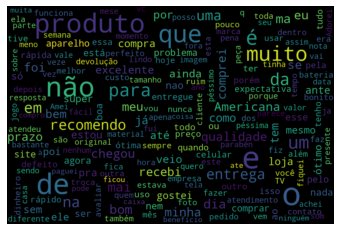

```python
import matplotlib.pyplot as plt
from wordcloud import WordCloud
%matplotlib inline

def show_wordcloud(dataframe: pd.DataFrame, text_column: str):
    all_words = ' '.join([ text for text in dataframe[text_column] ])
    word_cloud = \
        WordCloud(width=1200, height=800,
                  max_font_size=120, collocations=False).generate(all_words)
    plt.imshow(word_cloud, interpolation='bilinear')
    plt.axis('off')
    plt.show()

show_wordcloud(b2wReviews1, "review_text")
```

Podemos observar um grande número de conectores e artigos da lingua portuguesa, como "o", "de", "um", "em". Esses termos não interssam para a nossa classificação, e sua presença indica a necessidade de pré processar os dados antes de treinar os modelos.

### Pré processamento das avaliações

O pré-processamento de texto é uma etapa crítica na classificação de texto e em tarefas de processamento de linguagem natural (NLP) em geral. Existem várias razões pelas quais o pré-processamento de texto é importante:

- Normalização de Dados: O pré-processamento ajuda a normalizar os dados textuais, o que significa que ele coloca os textos em um formato consistente e padronizado. Isso é importante porque diferentes textos podem conter formatação, capitalização e estruturas diferentes, o que pode dificultar a comparação e análise.
- Redução de Ruído: Textos muitas vezes contêm informações irrelevantes, como espaços em branco extras, pontuação, caracteres especiais e tags HTML. O pré-processamento ajuda a eliminar esses elementos indesejados, o que melhora a qualidade dos dados e evita que o modelo se distraia com informações desnecessárias.
- Remoção de Stopwords: Stopwords são palavras comuns, como "e", "em", "o", "a", "de", "que", que não contribuem significativamente para o significado do texto. A remoção de stopwords reduz a dimensionalidade dos dados e ajuda o modelo a se concentrar em palavras mais informativas.
- Stemming ou Lematização: Stemming e lematização são técnicas para reduzir as palavras à sua forma raiz. Isso ajuda a agrupar palavras semelhantes e a lidar com variações morfológicas. Por exemplo, "correr" e "correndo" podem ser reduzidos a "corr" pela técnica de stemming.
- Eliminação de Variações de Palavras: O pré-processamento também ajuda a lidar com variações de palavras, como singular/plural, tempos verbais e conjugações. Isso garante que o modelo possa reconhecer palavras relacionadas como equivalentes.
- Melhoria da Eficiência Computacional: Ao reduzir a quantidade de dados e melhorar a qualidade, o pré-processamento torna a análise de texto mais eficiente em termos de recursos computacionais.

```python
import re
from nltk.corpus import stopwords
from nltk.stem import SnowballStemmer

def preprocess_text(text):
    # Remoção de caracteres especiais e números
    text = re.sub(r'[^a-zA-Z]', ' ', text)
    # Remoção de stopwords
    words = text.lower().split()
    words = [word for word in words if word not in stopwords.words('portuguese')]
    # Stemming
    stemmer = SnowballStemmer('portuguese')
    words = [stemmer.stem(word) for word in words]
    return ' '.join(words)

b2wReviews1['processed_text'] = b2wReviews1['review_text'].apply(preprocess_text)
```

Agora, vamos analisar a nova nuvem de palavras, com o texto processado:

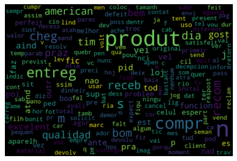

```python
show_wordcloud(b2wReviews1, "processed_text")
```

Podemos observar que além da remoção das palavras desnecessárias (conectores, artigos, etc.) as palavras aparecem em sua forma raiz, removendo assim a repetição de palavras, como no caso de "entrega" e "entregue", que são resumidos para "entreg", graças a técnica de stemming.  
Com isso, podemos seguir para a vetorização.

### Vetorização

A vetorização de textos é um processo fundamental na análise de sentimentos, que envolve a transformação de texto em dados numéricos que podem ser processados por algoritmos de aprendizado de máquina. Isso permite que os modelos de análise de sentimentos compreendam e classifiquem o conteúdo de texto com base em emoções, opiniões e polaridade, como positivo, negativo ou neutro.  
Para esse trabalho, vamos utilizar a técnica TF-IDF, que atribui um valor a cada palavra com base em sua frequência no documento e na frequência inversa em todo o corpus de documentos. Isso ajuda a destacar palavras importantes e reduzir o peso de palavras comuns.  
Primeiro, vamos separar o conjunto de dados em um conjunto de treino e um conjunto de validaçãom seguindo a proporção 80/20, com 80% sendo utilizado para treino e 20% para validação:

```python
from sklearn.model_selection import train_test_split
X_train, X_val, y_train, y_val = train_test_split(b2wReviews1['processed_text'], b2wReviews1['polarity'], test_size=0.2, random_state=42)
```

Em seguida, vamos utilizar o TF-IDF para vetorizar o textos pré processados de treino e validação:

```python
from sklearn.feature_extraction.text import TfidfVectorizer
vectorizer = TfidfVectorizer()
X_train_vect = vectorizer.fit_transform(X_train)
X_val_vect = vectorizer.transform(X_val)
```

### Treinando e avaliando modelos

Com os dados devidamento preparados, seguimos para a geração e avaliação dos modelos. Para isso, vamos gerar uma lista de modelos utilizando diferentes algoritmos de classifcação, e para cada um vamos realizar algumas métricas no conjunto de validação. As métricas utilizadas serão:

- Accuracy (Acurácia): A acurácia é uma métrica simples que mede a proporção de previsões corretas em relação ao número total de previsões. É útil para avaliar o desempenho geral de um modelo de classificação, especialmente quando as classes têm tamanhos aproximadamente iguais. No entanto, a acurácia pode ser enganosa em casos de desequilíbrio de classes, onde uma classe é muito mais predominante que a outra.
- F1 Micro (F1 Micro-averaged): O F1 Micro é uma medida de desempenho que calcula a média harmônica das métricas de precisão e recall a nível de instância e é adequado para problemas de classificação multiclasse. Ele leva em consideração as previsões corretas e incorretas para todas as classes, dando igual peso a cada classe. É útil quando o desequilíbrio de classes é um problema.
- F1 Macro (F1 Macro-averaged): O F1 Macro é semelhante ao F1 Micro, mas calcula a média harmônica das métricas de precisão e recall para cada classe separadamente e, em seguida, faz uma média simples desses valores. Diferentemente do F1 Micro, o F1 Macro dá igual peso a cada classe, independentemente do tamanho da classe. Isso o torna adequado quando você deseja avaliar o desempenho de um modelo em todas as classes de forma equitativa.
- Precision (Precisão): A precisão mede a proporção de instâncias classificadas como positivas que eram verdadeiramente positivas. Em outras palavras, é a capacidade do modelo de não fazer falsos positivos. Uma alta precisão significa que o modelo é bom em classificar apenas as instâncias que são realmente positivas.
- Recall (Revocação): A revocação mede a proporção de instâncias positivas que foram corretamente classificadas como positivas. É a capacidade do modelo de identificar todas as instâncias positivas, minimizando os falsos negativos. Uma alta revocação é importante em cenários onde identificar todas as instâncias positivas é crítico.

```python
from sklearn.linear_model import LogisticRegression
from sklearn.tree import DecisionTreeClassifier
from sklearn.ensemble import RandomForestClassifier
from sklearn.naive_bayes import MultinomialNB
from sklearn.model_selection import KFold, cross_validate
from sklearn.metrics import accuracy_score, precision_score, f1_score, recall_score

models = []
models.append(('MultinomialNB', MultinomialNB()))
models.append(('LogisticRegression', LogisticRegression(random_state=1, tol=1e-5,max_iter = 100000)))
models.append(('DecisionTreeClassifier', DecisionTreeClassifier()))
models.append(('RandomForestClassifier',RandomForestClassifier()))

metrics = ['accuracy', 'f1_micro', 'f1_macro', 'precision', 'recall']
results_df = pd.DataFrame(columns=['model'] + metrics)

for name, model in models:
    model.fit(X_train_vect, y_train)
    y_pred = model.predict(X_val_vect)
    accuracy = accuracy_score(y_val, y_pred)
    f1_micro = f1_score(y_val, y_pred, average='micro')
    f1_macro = f1_score(y_val, y_pred, average='macro')
    precision = precision_score(y_val, y_pred, average='weighted')
    recall = recall_score(y_val, y_pred, average='weighted')
    results_df = pd.concat([results_df, pd.DataFrame({'model': [name], 'accuracy': [accuracy], 'f1_micro': [f1_micro], 'f1_macro': [f1_macro], 'precision': [precision], 'recall': [recall]})], ignore_index=True)
```

Agora vamos obvservar os resultados:

|  | model | accuracy | f1_micro | f1_macro | precision | recall |
| --- | --- | --- | --- | --- | --- | --- |
| 0 | MultinomialNB | 0.91539 | 0.91539 | 0.915358 | 0.915818 | 0.91539 |
| 1 | LogisticRegression | 0.933452 | 0.933452 | 0.933436 | 0.933712 | 0.933452 |
| 2 | DecisionTreeClassifier | 0.869198 | 0.869198 | 0.869198 | 0.869216 | 0.869198 |
| 3 | RandomForestClassifier | 0.91761 | 0.91761 | 0.917579 | 0.918042 | 0.91761 |

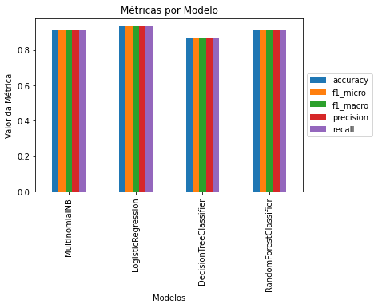

```python
results_df.set_index('model')[metrics].plot.bar(rot=0)
plt.xlabel('Modelos')
plt.ylabel('Valor da Métrica')
plt.title('Métricas por Modelo')
plt.xticks(rotation=90)
plt.legend(loc='center left', bbox_to_anchor=(1.0, 0.5))
results_df
```

Podemos observar que o modelo que apresentou os melhores valores para todas as métricas foi o LogisticRegression, portanto, vamos utilizar ele, e verificar seu desempenho para as duas polaridades:

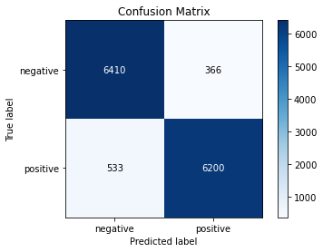

```python
import scikitplot as skplt
from sklearn.metrics import confusion_matrix , classification_report
selected_model = models[1][1]
predict = selected_model.predict(X_val_vect)
skplt.metrics.plot_confusion_matrix(y_val, predict)
```

Com a matriz de confusão acima, concluímos que o modelo tem um desempenho bom e semelhante tanto para a polaridade positiva quanto a negativa, ou seja, não está tendecioso.  
Por fim, vamos exportar o modelo escolhido, assim como o vetorizador TF-IDF:

```python
import pickle
pickle.dump(vectorizer, open('./models/vectorizer', 'wb'))
pickle.dump(selected_model, open('./models/LogisticRegressionTextClassifier', 'wb'))
```